# **Econometric Models in Practice**

### 8.5.2 Plot Jalur (Path Plot)

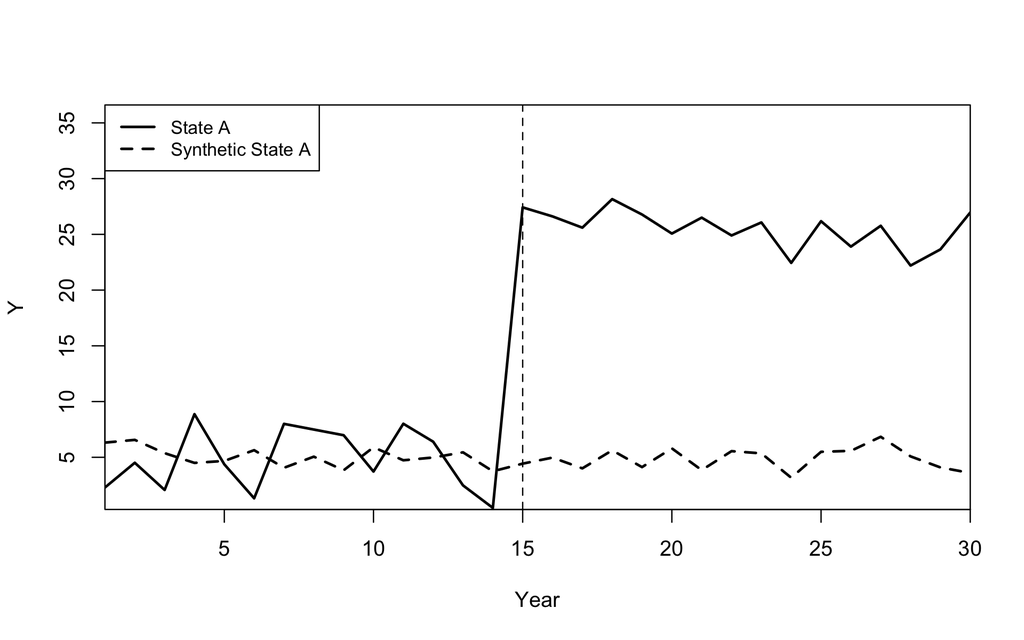

```r
path.plot(
  synth.res       = synth.out,
  dataprep.res    = dataprep.out,
  Ylab            = "Y",
  Xlab            = "Year",
  Legend          = c("State A", "Synthetic State A"),
  Legend.position = "topleft"
)
abline(v = 15, lty = 2)
```

### 8.5.3 Plot Gap

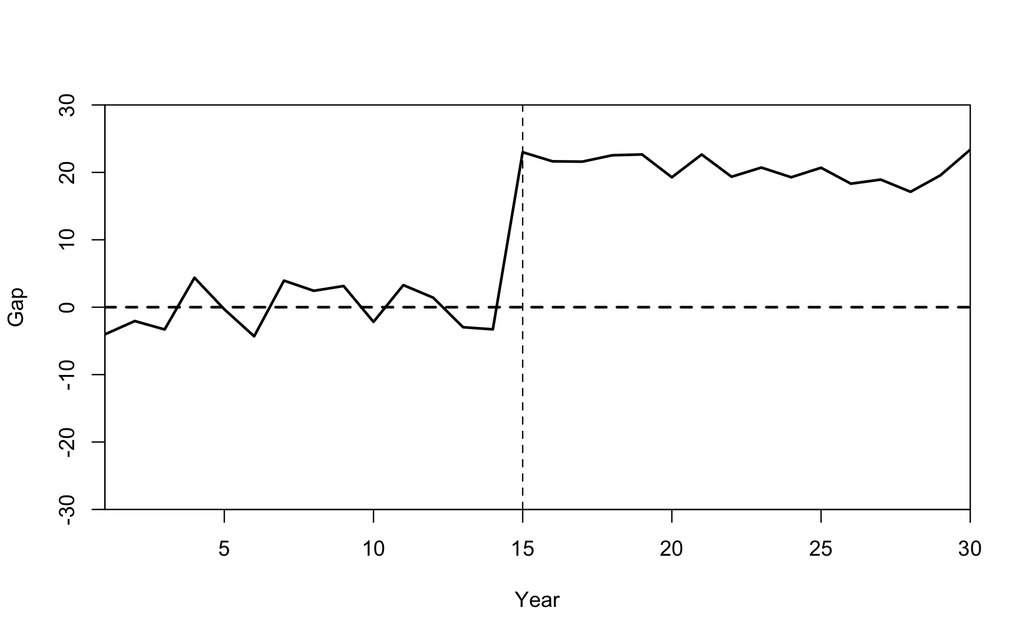

```r
gaps.plot(
  synth.res    = synth.out,
  dataprep.res = dataprep.out,
  Ylab         = "Gap",
  Xlab         = "Year",
  Ylim         = c(-30, 30),
  Main         = ""
)
abline(v = 15, lty = 2)
```

### 8.5.4 Estimasi dengan **gsynth**

`gsynth` memungkinkan *multiple treated units* dan komponen faktor laten (**iterative fixed effects**). Kita gunakan *two-way fixed effects* dengan *cross-validation* untuk memilih jumlah faktor `r`. Agar knitting mulus di berbagai lingkungan, kita set `parallel = FALSE` dan mengurangi `nboots`.

```r
gs.out <- gsynth(
  formula    = Y ~ T + X1 + X2,
  data       = df,
  index      = c("state", "year"),
  force      = "two-way",
  CV         = TRUE,
  r          = c(0, 5),
  se         = TRUE,
  inference  = "parametric",
  nboots     = 200,        # kurangi untuk mempercepat knit
  parallel   = FALSE       # TRUE di mesin lokal jika ingin lebih cepat
)
```

```
## Cross-validating ...
##  r = 0; sigma2 = 1.13533; IC = 0.95632; PC = 0.96713; MSPE = 1.65502
##  r = 1; sigma2 = 0.96885; IC = 1.54420; PC = 4.30644; MSPE = 1.33375
##  r = 2; sigma2 = 0.81855; IC = 2.08062; PC = 6.58556; MSPE = 1.27341*
##  r = 3; sigma2 = 0.71670; IC = 2.61125; PC = 8.35187; MSPE = 1.79319
##  r = 4; sigma2 = 0.62823; IC = 3.10156; PC = 9.59221; MSPE = 2.02301
##  r = 5; sigma2 = 0.55497; IC = 3.55814; PC = 10.48406; MSPE = 2.79596
##
##  r* = 2
##
## Simulating errors .....Bootstrapping ...
## ..
```

```r
gs.out
```

```
## Call:
## gsynth.formula(formula = Y ~ T + X1 + X2, data = df, index = c("state",
##     "year"), force = "two-way", r = c(0, 5), CV = TRUE, se = TRUE,
##     nboots = 200, inference = "parametric", parallel = FALSE)
##
## Average Treatment Effect on the Treated:
##         Estimate   S.E. CI.lower CI.upper p.value
## ATT.avg    20.45 0.7141    19.06    21.85       0
##
##    ~ by Period (including Pre-treatment Periods):
##          ATT   S.E. CI.lower CI.upper   p.value n.Treated
## -13 -0.43323 1.0923  -2.5741   1.7076 6.916e-01         0
## -12 -0.78276 0.9471  -2.6390   1.0735 4.085e-01         0
## -11 -0.19199 0.9309  -2.0165   1.6325 8.366e-01         0
## -10 -0.98289 1.0057  -2.9540   0.9882 3.284e-01         0
## -9  -0.94504 0.8148  -2.5419   0.6519 2.461e-01         0
## -8  -0.23970 0.9051  -2.0136   1.5342 7.911e-01         0
## -7   1.74468 1.1957  -0.5988   4.0882 1.445e-01         0
## -6   1.73998 1.2365  -0.6836   4.1636 1.594e-01         0
## -5   0.63689 0.9037  -1.1343   2.4081 4.810e-01         0
## -4  -0.03246 0.8872  -1.7713   1.7063 9.708e-01         0
## -3  -0.25405 0.8082  -1.8380   1.3299 7.533e-01         0
## -2   0.10273 0.8376  -1.5390   1.7445 9.024e-01         0
## -1  -0.23391 0.5835  -1.3776   0.9097 6.885e-01         0
## 0   -0.12827 0.9169  -1.9253   1.6688 8.887e-01         0
## 1   21.19473 1.7697  17.7263  24.6632 0.000e+00         1
## 2   22.84214 1.2183  20.4544  25.2299 0.000e+00         1
## 3   20.36902 1.2826  17.8552  22.8829 0.000e+00         1
## 4   22.33201 1.9629  18.4848  26.1793 0.000e+00         1
## 5   19.68346 2.4703  14.8417  24.5252 1.554e-15         1
## 6   18.08863 0.8339  16.4541  19.7231 0.000e+00         1
## 7   19.75869 1.3372  17.1378  22.3796 0.000e+00         1
## 8   18.92529 1.9750  15.0543  22.7963 0.000e+00         1
## 9   21.74294 0.9219  19.9360  23.5499 0.000e+00         1
## 10  21.64782 0.9279  19.8291  23.4665 0.000e+00         1
## 11  19.39832 1.3055  16.8396  21.9570 0.000e+00         1
## 12  19.31785 0.8282  17.6946  20.9411 0.000e+00         1
## 13  22.28342 1.1193  20.0895  24.4773 0.000e+00         1
## 14  20.38876 0.9184  18.5888  22.1888 0.000e+00         1
## 15  18.92550 1.5937  15.8019  22.0491 0.000e+00         1
## 16  20.37687 1.6095  17.2223  23.5314 0.000e+00         1
##
## Coefficients for the Covariates:
##       beta    S.E. CI.lower CI.upper p.value
## X1 1.93082 0.06295  1.80745   2.0542  0.0000
## X2 0.03809 0.04610 -0.05227   0.1284  0.4087
```

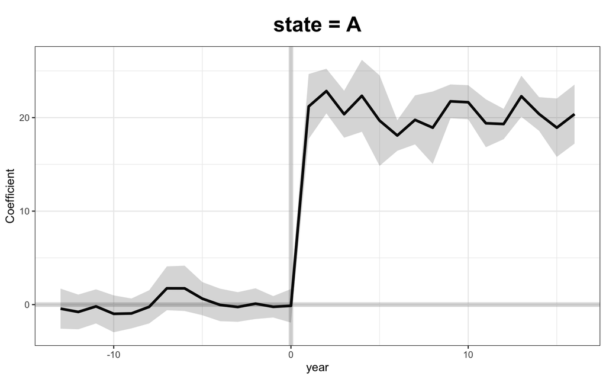

```r
# Plot utama
plot(gs.out)
```

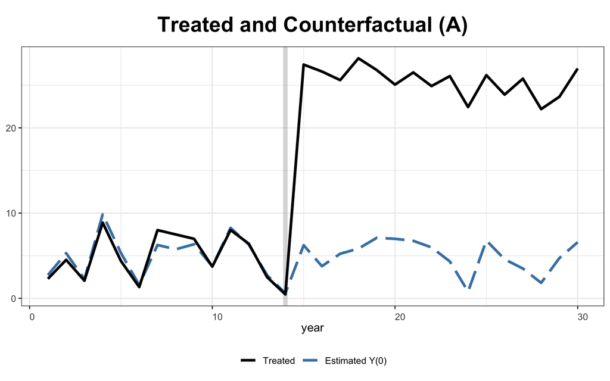

```r
# Counterfactual (trajektori aktual vs counterfactual untuk unit treated)
plot(gs.out, type = "counterfactual")
```

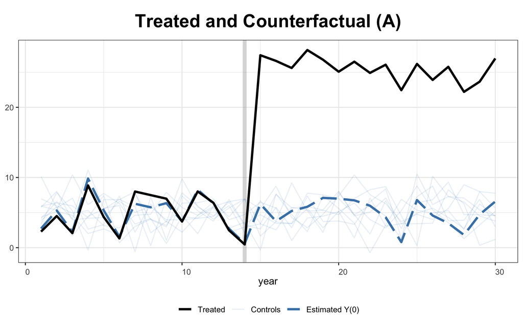

```r
# Estimasi untuk semua kontrol (raw = "all")
plot(gs.out, type = "counterfactual", raw = "all")
```

### 8.5.5 Menghindari Error Umum

- **`unit.variable not found as numeric variable in foo`**  
  Pastikan kolom yang dipakai sebagai `unit.variable` **numeric** (contoh: `state.num`). Jika masih gagal, cek apakah nama kolom sesuai (ejaan tepat).
- **`X1,X0,Z1,Z0 were individually input`** (pesan informasi)  
  Itu normal saat `synth()` dipanggil menggunakan objek `dataprep`.
- **Plot tidak muncul saat knit**  
  Pastikan chunk tidak `echo=FALSE` dan tidak `fig.show='hide'`.

# 9 **Vector Autoregressive Model (VAR)**

## 9.1 Apa itu VAR?

**Vector Autoregression (VAR)** adalah model untuk beberapa variabel time‑series yang saling mempengaruhi secara dinamis. Setiap variabel dijelaskan oleh *lag* dirinya **dan** *lag* variabel lain. Intuisinya: ekonomi itu ngobrol—bukan monolog—jadi modelnya juga *multi-way conversations*.

Secara ringkas, VAR cocok ketika:

- kita punya beberapa seri yang mungkin saling memengaruhi,
- tidak ingin memaksakan struktur kausal yang kaku di awal,
- fokus pada peramalan, *impulse response*, dan *variance decomposition*.

## 9.2 Spesifikasi Model

Untuk vektor \(y_t\in\mathbb{R}^K\) dan lag orde \(p\), model **VAR(p)**: \[ y_t = c + A_1 y_{t-1} + A_2 y_{t-2} + \cdots + A_p y_{t-p} + u_t,\quad u_t\sim \text{i.i.d. }(0,\,\Sigma_u), \]

dengan: - \(c\) vektor intersep \((K\times 1)\), - \(A_j\) matriks koefisien \((K\times K)\), - \(u_t\) inovasi *white noise* kovarian \(\Sigma_u\).

**Bentuk persamaan per variabel (misal \(K=2\))**:

$$\begin{aligned}
y_{1t} &= c_1 + \sum_{j=1}^p a^{(11)}_{j}\,y_{1,t-j} + \sum_{j=1}^p
a^{(12)}_{j}\,y_{2,t-j} + u_{1t},\\
y_{2t} &= c_2 + \sum_{j=1}^p a^{(21)}_{j}\,y_{1,t-j} + \sum_{j=1}^p
a^{(22)}_{j}\,y_{2,t-j} + u_{2t}.
\end{aligned}$$

## 9.3 Ide yang Melandasi

- **Endogenitas bersama:** semua variabel dianggap endogen dalam sistem.
- **Parsimonious but rich:** cukup fleksibel menangkap dinamika silang, tanpa mengasumsikan arah kausal *a priori*.
- **Analisis dinamika kebijakan/shock:** lewat **Impulse Response Function (IRF)** dan **Forecast Error Variance Decomposition (FEVD)**.

## 9.4 Asumsi Penting

1. **Stasioneritas (weak/kovarian):** nilai harapan konstan, varians konstan, kovarians hanya fungsi dari lag. Secara praktis: akar polinomial karakteristik (akar dari *companion matrix*) berada **di luar** lingkaran satuan (|root| > 1).
2. **Inovasi white noise:** \(u_t\) tak berkorelasi serial, \(\mathbb{E}(u_t)=0\), kovarian konstan \(\Sigma_u\).
3. **Tidak ada *perfect multicollinearity*** di regresor (lag-lag).
4. **Ukuran sampel memadai** relatif terhadap parameter (VAR bisa cepat “haus data”).

> Bila data punya *unit root* (non‑stationary) dan **tidak kointegrasi**, gunakan *differences*. Bila **terkointegrasi**, gunakan **VECM** (VAR terbatas) dan, bila perlu, transform ke **SVAR/IRF** struktural.

## 9.5 Stasioneritas

**Stasioneritas** (stationarity) adalah salah satu asumsi terpenting dalam analisis deret waktu.  
Sebuah proses deret waktu disebut *stasioner* bila **sifat-sifat statistiknya tidak berubah sepanjang waktu**.

Secara intuitif, pada deret yang stasioner: - Rata-rata tetap konstan, - Varians tidak meningkat/menurun seiring waktu, - Pola kovarians hanya bergantung pada jarak antar pengamatan (lag), bukan pada waktu spesifik.

### 9.5.1 Jenis Stasioneritas

#### 9.5.1.1 Stasioneritas Kuat (Strict Stationarity)

Artinya: seluruh bentuk distribusi (mean, varians, skewness, kurtosis, dll) **tidak berubah terhadap waktu**.

#### 9.5.1.2 Stasioneritas Lemah (Weak / Covariance Stationarity)

Lebih sering digunakan dalam praktik, terutama di ekonometrika.

### 9.5.2 Mengapa Stasioneritas Penting?

1. **Konsistensi dan validitas model VAR, ARIMA, dll.**  
   Banyak metode asumsi model linier (OLS, VAR, ARMA) membutuhkan data dengan varians konstan dan hubungan stabil antar waktu.
2. **Mencegah hubungan palsu (spurious regression)**.  
   Jika dua deret bersifat tren (non-stasioner), regresi antar keduanya bisa menunjukkan hubungan kuat padahal semu.
3. **Diperlukan untuk inferensi statistik.**  
   Tanpa stasioneritas, hasil uji signifikansi (t, F) menjadi tidak valid karena pelanggaran asumsi homoskedastisitas dan independensi residual.

### 9.5.3 Ciri-ciri Deret Non-Stasioner

- Tren naik atau turun yang jelas.
- Varians meningkat seiring waktu (heteroskedastisitas).
- Nilai autokorelasi (ACF) menurun sangat lambat.
- Hasil uji unit root signifikan (ada akar unit).

Contoh visual sederhana:

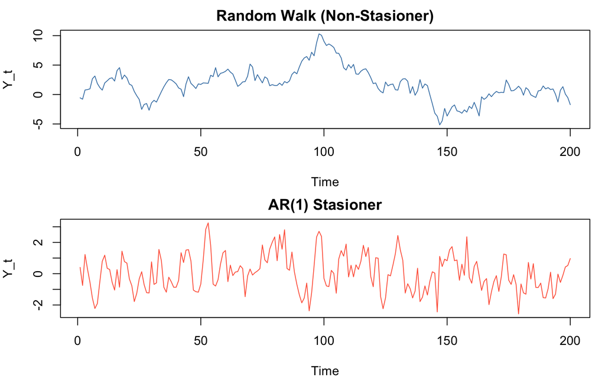

```r
set.seed(123)
t <- 1:200
yt_nonstat <- cumsum(rnorm(200))   # random walk
yt_stat    <- arima.sim(list(ar=0.6), n=200)  # AR(1) stasioner

par(mfrow=c(2,1), mar=c(4,4,2,1))
plot(t, yt_nonstat, type="l", col="steelblue", main="Random Walk (Non-Stasioner)", ylab="Y_t", xlab="Time")
plot(t, yt_stat, type="l", col="tomato", main="AR(1) Stasioner", ylab="Y_t", xlab="Time")
```

### 9.5.4 Uji Stasioneritas (Unit Root Test)

#### 9.5.4.1 Augmented Dickey–Fuller (ADF) Test

Hipotesis: - \(H_0\): ada akar unit → **non-stasioner** - \(H_1\): tidak ada akar unit → **stasioner**

```r
library(urca)
set.seed(123)
y_rw <- cumsum(rnorm(100))
adf_rw <- ur.df(y_rw, type = "trend", selectlags = "AIC")
summary(adf_rw)
```

```
##
## ###############################################
## # Augmented Dickey-Fuller Test Unit Root Test #
## ###############################################
##
## Test regression trend
##
##
## Call:
## lm(formula = z.diff ~ z.lag.1 + 1 + tt + z.diff.lag)
##
## Residuals:
##      Min       1Q   Median       3Q      Max
## -2.29892 -0.55589 -0.05452  0.56848  2.22751
##
## Coefficients:
##              Estimate Std. Error t value Pr(>|t|)
## (Intercept)  0.006309   0.188944   0.033   0.9734
## z.lag.1     -0.101367   0.052706  -1.923   0.0575 .
## tt           0.006680   0.004035   1.656   0.1011
## z.diff.lag   0.034148   0.108236   0.315   0.7531
## ---
## Signif. codes:  0 '***' 0.001 '**' 0.01 '*' 0.05 '.' 0.1 ' ' 1
##
## Residual standard error: 0.9135 on 94 degrees of freedom
## Multiple R-squared:  0.04288,    Adjusted R-squared:  0.01233
## F-statistic: 1.404 on 3 and 94 DF,  p-value: 0.2466
##
##
## Value of test-statistic is: -1.9233 1.7897 2.065
##
## Critical values for test statistics:
##       1pct  5pct 10pct
## tau3 -4.04 -3.45 -3.15
## phi2  6.50  4.88  4.16
## phi3  8.73  6.49  5.47
```

Jika nilai *test statistic* lebih kecil dari nilai kritis (atau p-value < 0.05), maka deret stasioner.

Alternatif ADF yang lebih robust terhadap autokorelasi dan heteroskedastisitas.

```r
library(tseries)
pp.test(y_rw)
```

```
##
##  Phillips-Perron Unit Root Test
##
## data:  y_rw
## Dickey-Fuller Z(alpha) = -10.405, Truncation lag parameter = 3, p-value
## = 0.5121
## alternative hypothesis: stationary
```

#### 9.5.4.2 Kwiatkowski–Phillips–Schmidt–Shin (KPSS) Test

Kebalikan dari ADF: - \(H_0\): stasioner - \(H_1\): non-stasioner

```r
kpss.test(y_rw)
```

```
##
##  KPSS Test for Level Stationarity
##
## data:  y_rw
## KPSS Level = 0.95298, Truncation lag parameter = 4, p-value = 0.01
```

Kombinasi hasil ADF + KPSS sering dipakai: - ADF gagal menolak H0 & KPSS menolak H0 → non-stasioner.  
- ADF menolak H0 & KPSS gagal menolak H0 → stasioner.

### 9.5.5 Penanganan Data Non-Stasioner

**Kesimpulan**

| Aspek | Stasioner | Non-Stasioner |
| --- | --- | --- |
| Rata-rata | Konstan | Berubah (tren) |
| Varians | Konstan | Meningkat/berubah |
| Kovarians | Bergantung pada lag | Bergantung pada waktu |
| Uji ADF | Tolak H0 | Gagal tolak H0 |
| Tindakan | Gunakan langsung | Differencing / transformasi |

## 9.6 Estimasi Parameter

- VAR diestimasi **persamaan-per-persamaan** memakai **OLS** karena regresor sama di setiap persamaan (blok lag vektor \(y\)).
- OLS konsisten & efisien (di kelas *seemingly unrelated regressions* dengan identik regresor).

### 9.6.1 Model VAR(p) singkat padat

Misalkan terdapat $K$ variabel endogen yang disusun dalam vektor:
$$Y_t = \begin{bmatrix} y_{1t}\\ y_{2t}\\ \vdots\\ y_{Kt}\end{bmatrix}.$$

Model **VAR(p)** ditulis sebagai
$$Y_t \;=\; c \;+\; A_1 Y_{t-1} \;+\; \cdots \;+\; A_p Y_{t-p} \;+\;
u_t,\qquad
E(u_t)=0,\; E(u_t u_t^\top)=\Sigma_u,$$
dengan $c$ vektor konstanta berukuran $K\times 1$, $A_i$ matriks $K\times K$, dan $u_t$ vektor gangguan.

**Contoh VAR(1) dua variabel:**
$$\begin{aligned}
y_{1t} &= c_1 + a^{(11)}_1\,y_{1,t-1} + a^{(12)}_1\,y_{2,t-1} +
u_{1t},\\
y_{2t} &= c_2 + a^{(21)}_1\,y_{1,t-1} + a^{(22)}_1\,y_{2,t-1} +
u_{2t}.
\end{aligned}$$

### 9.6.2 Estimasi (OLS persamaan-per-persamaan)

VAR standar diestimasi dengan **OLS** untuk tiap persamaan karena sisi kanan (RHS) identik: konstanta + seluruh lag semua variabel.

Untuk lag $p=1$, definisikan matriks regresor dan respons (untuk $t=2,\dots,T$):
$$X = \begin{bmatrix}
1 & y_{1,1} & y_{2,1} & \cdots & y_{K,1}\\
1 & y_{1,2} & y_{2,2} & \cdots & y_{K,2}\\
\vdots & \vdots & \vdots & \ddots & \vdots\\
1 & y_{1,T-1} & y_{2,T-1} & \cdots & y_{K,T-1}
\end{bmatrix},\qquad
Y = \begin{bmatrix}
y_{1,2} & y_{2,2} & \cdots & y_{K,2}\\
y_{1,3} & y_{2,3} & \cdots & y_{K,3}\\
\vdots & \vdots & \ddots & \vdots\\
y_{1,T} & y_{2,T} & \cdots & y_{K,T}
\end{bmatrix}.$$

Estimator OLS serentak (kolom-per-kolom):
$$\widehat{B} \;=\; (X^\top X)^{-1} X^\top Y,$$
dengan dimensi $\widehat{B} \in \mathbb{R}^{(1+Kp)\times K}$. Kovarians residual:
$$\widehat{\Sigma}_u \;=\; \frac{1}{T_{\mathrm{ef}}-(1+Kp)}\sum_{t}
\widehat{u}_t\widehat{u}_t^\top,\qquad
\widehat{u}_t = Y_t - X_t \widehat{B}.$$

### 9.6.3 Contoh perhitungan manual (VAR(1), K=2)

Ambil data mungil (agar mudah dihitung tangan). Observasi $t=1,\dots,6$.

- $y_1 = [2,\,3,\,5,\,4,\,6,\,7]$
- $y_2 = [1,\,2,\,1,\,3,\,2,\,4]$

Untuk VAR(1), data efektif $t=2,\dots,6$ (karena butuh lag). Susun $X$ (konstanta + lag $y_1$ + lag $y_2$) dan $Y$ (nilai saat ini):

$$X=\begin{bmatrix}
1 & 2 & 1\\
1 & 3 & 2\\
1 & 5 & 1\\
1 & 4 & 3\\
1 & 6 & 2
\end{bmatrix},\qquad
Y=\begin{bmatrix}
3 & 2\\
5 & 1\\
4 & 3\\
6 & 2\\
7 & 4
\end{bmatrix}.$$

Komponen OLS (telah dihitung):
$$X^\top
X=\begin{bmatrix}5&20&9\\20&90&37\\9&37&19\end{bmatrix},\quad
X^\top Y_{\cdot,1}=\begin{bmatrix}25\\107\\49\end{bmatrix},\quad
X^\top Y_{\cdot,2}=\begin{bmatrix}12\\54\\21\end{bmatrix},$$
$$(X^\top X)^{-1}=\begin{bmatrix}
2.52592593 & -0.34814815 & -0.51851852\\
-0.34814815 & 0.10370370 & -0.03703704\\
-0.51851852 & -0.03703704 & 0.37037037
\end{bmatrix}.$$

Koefisien OLS:
$$\widehat{\beta}_{y_1}=\begin{bmatrix}0.48888889\\0.57777778\\1.22222222\end{bmatrix},\qquad
\widehat{\beta}_{y_2}=\begin{bmatrix}0.62222222\\0.64444444\\-0.44444444\end{bmatrix}.$$

Artinya, estimasi persamaan:
$$\begin{aligned}
\widehat{y}_{1t} &= 0.4889 + 0.5778\,y_{1,t-1} +
1.2222\,y_{2,t-1},\\
\widehat{y}_{2t} &= 0.6222 + 0.6444\,y_{1,t-1} - 0.4444\,y_{2,t-1}.
\end{aligned}$$

Residual ringkas (untuk $t=2,\dots,6$) dan kovariansnya:
$$\widehat{\Sigma}_u=\begin{bmatrix}0.5333&0.1333\\0.1333&0.5333\end{bmatrix}
\quad (\text{dengan pembagi } T_{\mathrm{ef}}-k = 5-3 = 2).$$

**Satu-langkah ramalan** ke $t=7$ (pakai $y_{1,6}=7, y_{2,6}=4$):
$$\widehat{y}_{1,7}=0.4889 + 0.5778(7) + 1.2222(4) \approx 9.4222,\quad
\widehat{y}_{2,7}=0.6222 + 0.6444(7) - 0.4444(4) \approx 3.3556.$$

### 9.6.4 Uji & Diagnostik penting

- **Pemilihan lag** $p$: AIC, BIC, HQ.
- **Stasioneritas**: pastikan tiap variabel stasioner; jika tidak, gunakan differencing atau VECM bila terkointegrasi.
- **Stabilitas VAR**: nilai eigen *companion matrix* harus bermodulus < 1.
- **IRF & FEVD**: analisis dinamika shock dan komposisi varians kesalahan ramalan.

**Replikasi cepat di R**

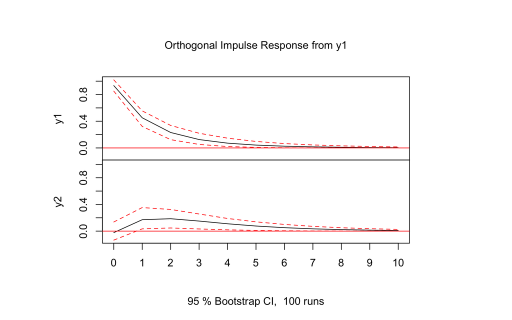

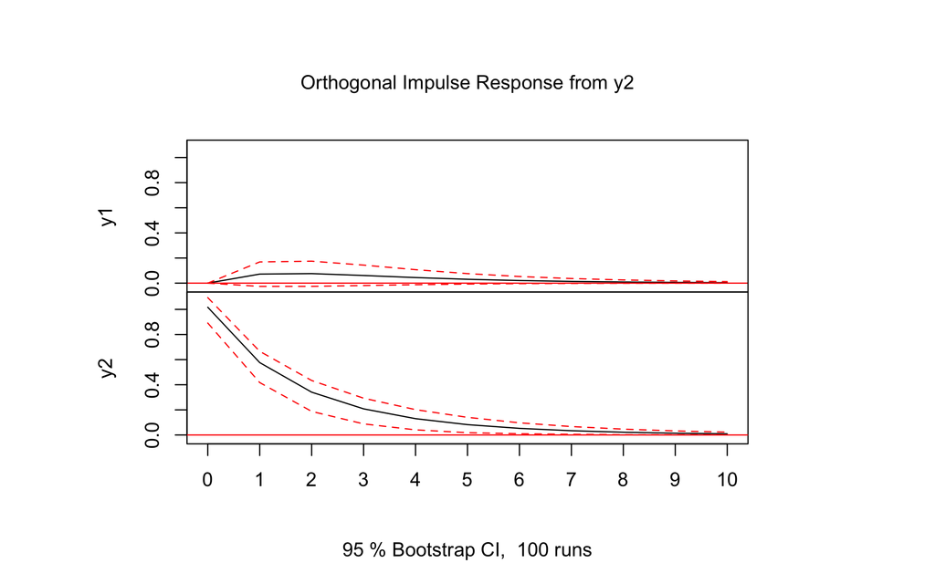

```r
set.seed(1)
T <- 200
e <- matrix(rnorm(2*T), ncol = 2)
Y <- matrix(0, nrow = T, ncol = 2)
A <- matrix(c(0.5, 0.2,
              0.1, 0.6), 2, 2)  # stabil (akar < 1)

for(t in 2:T) Y[t,] <- c(0,0) + A %*% Y[t-1,] + e[t,]
dat <- data.frame(y1 = Y[,1], y2 = Y[,2])

library(vars)
m_big <- VAR(dat, p = 1, type = "const")

# IRF ortogonal sekarang aman:
plot(irf(m_big, boot = TRUE))
```

**Ringkasan**

- **Model**: semua variabel endogen, dipengaruhi lag dirinya & variabel lain.
- **Estimasi**: OLS per persamaan dengan rumus matriks standar.
- **Contoh manual**: disajikan lengkap (X, $X^\top X$, invers, koefisien, residual, $\Sigma_u$, ramalan).
- **Lanjutan**: pilih lag optimal, cek stasioneritas & stabilitas, analisis IRF/FEVD untuk interpretasi dinamis.

## 9.7 Pemilihan Orde Lag

Pilih $p$ via **kriteria informasi**: **AIC**, **BIC/SC**, dan **HQ**.  
Secara praktis: - **AIC** sering memilih model **lebih besar** (baik untuk *forecasting* karena *in-sample fit* lebih longgar). - **BIC/SC** memberi penalti lebih kuat → model **lebih hemat parameter** (baik untuk penjelasan/parsimonious). - **HQ** berada di antara AIC dan BIC (kompromi).

**Formulasi Umum untuk VAR($p$)**

Misal sistem $K$ variabel dengan kovarians residual $\widehat{\Sigma}_u(p)$ dan jumlah observasi efektif $T$. Kriteria untuk lag $p$:

$$\text{AIC}(p) \;=\; \ln\!\big|\widehat{\Sigma}_u(p)\big| \;+\;
\frac{2\,K^2\,p}{T},$$

$$\text{BIC}(p) \;=\; \ln\!\big|\widehat{\Sigma}_u(p)\big| \;+\;
\frac{\ln(T)\,K^2\,p}{T},$$

$$\text{HQ}(p) \;=\; \ln\!\big|\widehat{\Sigma}_u(p)\big| \;+\;
\frac{2\,\ln\!\big(\ln T\big)\,K^2\,p}{T}.$$

> Catatan: Banyak paket menggunakan bentuk yang ekuivalen (berbeda konstanta/pembagi) namun **memberi ranking yang sama**. Inti dari semua kriteria adalah kompromi antara *goodness-of-fit* (kecilkan $|\widehat{\Sigma}_u|$) dan penalti kompleksitas (besar saat $p$ dan $K$ naik).

**Prosedur Praktis**

1. Tentukan rentang kandidat $p \in \{0,\dots,p_{\max}\}$ (mis. 6–12 untuk bulanan, 4–8 untuk kuartalan).
2. Estimasi VAR untuk tiap $p$ dan hitung AIC/BIC/HQ.
3. Pilih $p$ yang **meminimalkan** kriteria.
4. **Validasi**: cek stabilitas (akar eigen), uji autokorelasi residual (Ljung–Box/Portmanteau), dan *out-of-sample* jika fokusnya ramalan.

**Implementasi di R**

Menggunakan paket `vars`, fungsi `VARselect()` menghitung AIC, HQ, SC (BIC), dan FPE.

```r
suppressPackageStartupMessages({ library(vars) })

data("Canada", package = "vars")

# Tentukan kandidat lag 1..8 (contoh; sesuaikan frekuensi & data)
sel <- VARselect(Canada, lag.max = 8, type = "const")
sel
```

```
## $selection
## AIC(n)  HQ(n)  SC(n) FPE(n)
##      3      2      1      3
##
## $criteria
##                   1            2            3            4            5
## AIC(n) -6.005397982 -6.493055228 -6.590460263 -6.405675934 -6.162458245
## HQ(n)  -5.760273303 -6.051830805 -5.953136097 -5.572252025 -5.132934593
## SC(n)  -5.392047103 -5.389023645 -4.995747977 -4.320282945 -3.586384553
## FPE(n)  0.002467286  0.001520693  0.001392193  0.001703788  0.002235091
##                   6            7            8
## AIC(n) -6.063112372 -5.814371694 -5.796841456
## HQ(n)  -4.837488976 -4.392648555 -4.179018573
## SC(n)  -2.996357977 -2.256936595 -1.748725654
## FPE(n)  0.002576015  0.003511359  0.003887711
```

Output `sel$criteria` menampilkan nilai AIC, HQ, SC (BIC), dan FPE untuk tiap $p$. Rekomendasi paket ditunjukkan pada `sel$selection`.

```r
sel$selection
```

```
## AIC(n)  HQ(n)  SC(n) FPE(n)
##      3      2      1      3
```

**Pemilihan Otomatis & Estimasi Model**

Misal kita ambil **BIC** sebagai acuan, lalu estimasi VAR dengan p yang dipilih:

```r
p_bic <- sel$selection["SC(n)"]  # SC = Schwarz Criterion (BIC)
m_bic <- VAR(Canada, p = p_bic, type = "const")

summary(m_bic)      # ringkasan koefisien
```

```
##
## VAR Estimation Results:
## =========================
## Endogenous variables: e, prod, rw, U
## Deterministic variables: const
## Sample size: 83
## Log Likelihood: -213.774
## Roots of the characteristic polynomial:
## 0.9928 0.9526 0.9526 0.7511
## Call:
## VAR(y = Canada, p = p_bic, type = "const")
##
##
## Estimation results for equation e:
## ==================================
## e = e.l1 + prod.l1 + rw.l1 + U.l1 + const
##
##           Estimate Std. Error t value Pr(>|t|)
## e.l1       1.17354    0.08196  14.319  < 2e-16 ***
## prod.l1    0.14479    0.02741   5.282 1.13e-06 ***
## rw.l1     -0.07905    0.02832  -2.791  0.00660 **
## U.l1       0.52438    0.16574   3.164  0.00222 **
## const   -192.56361   63.81154  -3.018  0.00344 **
## ---
## Signif. codes:  0 '***' 0.001 '**' 0.01 '*' 0.05 '.' 0.1 ' ' 1
##
##
## Residual standard error: 0.4798 on 78 degrees of freedom
## Multiple R-Squared: 0.9973,  Adjusted R-squared: 0.9972
## F-statistic:  7304 on 4 and 78 DF,  p-value: < 2.2e-16
##
##
## Estimation results for equation prod:
## =====================================
## prod = e.l1 + prod.l1 + rw.l1 + U.l1 + const
##
##          Estimate Std. Error t value Pr(>|t|)
## e.l1      0.08710    0.11823   0.737    0.464
## prod.l1   1.01970    0.03955  25.785   <2e-16 ***
## rw.l1    -0.02629    0.04085  -0.644    0.522
```

[output cut: 48 more lines]

```
##
##
## Covariance matrix of residuals:
##             e     prod       rw        U
## e     0.23020  0.05311 -0.10293 -0.14055
## prod  0.05311  0.47903  0.02617 -0.02913
## rw   -0.10293  0.02617  0.62281  0.08092
## U    -0.14055 -0.02913  0.08092  0.12875
##
## Correlation matrix of residuals:
##            e    prod      rw       U
## e     1.0000  0.1599 -0.2718 -0.8164
## prod  0.1599  1.0000  0.0479 -0.1173
## rw   -0.2718  0.0479  1.0000  0.2857
## U    -0.8164 -0.1173  0.2857  1.0000
```

```r
roots(m_bic)        # cek stabilitas (harus < 1)
```

```
## [1] 0.9927905 0.9526365 0.9526365 0.7511478
```

```r
serial.test(m_bic)  # uji autokorelasi residual (Portmanteau)
```

```
##
##  Portmanteau Test (asymptotic)
##
## data:  Residuals of VAR object m_bic
## Chi-squared = 231.69, df = 240, p-value = 0.638
```

**Tips Praktis & Heuristik**

- **Data dengan musiman kuat**: pertimbangkan termasuk dummy musiman atau gunakan VAR pada data yang sudah disesuaikan.
- **Sampel pendek**: cenderung pilih **p kecil** (BIC).
- **Tujuan peramalan**: AIC kadang memberi akurasi lebih baik (tapi waspadai overfitting).
- **Konsistensi**: jika AIC dan BIC berbeda jauh, cek IRF/FEVD/stabilitas pada kedua pilihan; pilih yang paling stabil dan residualnya paling “bersih”.
- **Kointegrasi**: bila variabel I(1) dan saling terkointegrasi, gunakan **VECM**; pemilihan lag dilakukan pada VAR dalam level sebagai langkah awal penentuan orde error-correction.

## 9.8 Diagnostik & Stabilitas

Diagnostik pasca-estimasi pada VAR penting untuk memastikan model **valid** dan **stabil** sebelum melakukan IRF/FEVD/forecast. Fokus utama: - **Serial correlation** inovasi (uji Portmanteau / LM), - **Normalitas** residu (opsional, berguna untuk inferensi parametrik / bootstrap yang andal), - **ARCH effects** (heteroskedastisitas bersyarat), - **Stabilitas** sistem (akar/roots harus berada **di dalam** unit circle untuk *companion matrix* → untuk paket `vars`, kriteria stabilitas adalah **modulus akar < 1**).

> Catatan: beberapa buku teks menuliskan “akar di luar unit circle” ketika mereka mendefinisikan polinomial karakteristik secara terbalik. Di `vars`, fungsi `roots()` mengembalikan **modulus** dan **stabil** jika semuanya **< 1**.

### 9.8.1 Data & Estimasi Model Contoh

```r
suppressPackageStartupMessages({ library(vars) })
data("Canada", package = "vars")

# Pilih lag menggunakan BIC sebagai contoh
sel   <- VARselect(Canada, lag.max = 8, type = "const")
p_bic <- sel$selection["SC(n)"]
m     <- VAR(Canada, p = p_bic, type = "const")

summary(m)
```

```
##
## VAR Estimation Results:
## =========================
## Endogenous variables: e, prod, rw, U
## Deterministic variables: const
## Sample size: 83
## Log Likelihood: -213.774
## Roots of the characteristic polynomial:
## 0.9928 0.9526 0.9526 0.7511
## Call:
## VAR(y = Canada, p = p_bic, type = "const")
##
##
## Estimation results for equation e:
## ==================================
## e = e.l1 + prod.l1 + rw.l1 + U.l1 + const
##
##           Estimate Std. Error t value Pr(>|t|)
## e.l1       1.17354    0.08196  14.319  < 2e-16 ***
## prod.l1    0.14479    0.02741   5.282 1.13e-06 ***
## rw.l1     -0.07905    0.02832  -2.791  0.00660 **
## U.l1       0.52438    0.16574   3.164  0.00222 **
## const   -192.56361   63.81154  -3.018  0.00344 **
## ---
## Signif. codes:  0 '***' 0.001 '**' 0.01 '*' 0.05 '.' 0.1 ' ' 1
##
##
## Residual standard error: 0.4798 on 78 degrees of freedom
## Multiple R-Squared: 0.9973,  Adjusted R-squared: 0.9972
## F-statistic:  7304 on 4 and 78 DF,  p-value: < 2.2e-16
##
##
## Estimation results for equation prod:
## =====================================
## prod = e.l1 + prod.l1 + rw.l1 + U.l1 + const
##
##          Estimate Std. Error t value Pr(>|t|)
## e.l1      0.08710    0.11823   0.737    0.464
## prod.l1   1.01970    0.03955  25.785   <2e-16 ***
## rw.l1    -0.02629    0.04085  -0.644    0.522
```

[output cut: 48 more lines]

```
##
##
## Covariance matrix of residuals:
##             e     prod       rw        U
## e     0.23020  0.05311 -0.10293 -0.14055
## prod  0.05311  0.47903  0.02617 -0.02913
## rw   -0.10293  0.02617  0.62281  0.08092
## U    -0.14055 -0.02913  0.08092  0.12875
##
## Correlation matrix of residuals:
##            e    prod      rw       U
## e     1.0000  0.1599 -0.2718 -0.8164
## prod  0.1599  1.0000  0.0479 -0.1173
## rw   -0.2718  0.0479  1.0000  0.2857
## U    -0.8164 -0.1173  0.2857  1.0000
```

### 9.8.2 Serial Correlation: Portmanteau & LM

**Tujuan:** memeriksa apakah residual VAR masih punya autokorelasi multivariat.  
- **Portmanteau (Q-statistic)** menguji banyak lag sekaligus.  
- **LM (Breusch–Godfrey)** menguji autokorelasi hingga orde tertentu.

Hipotesis nol $H_0$: **tidak** ada autokorelasi hingga lag yang diuji.

```r
# Uji Portmanteau (default: hingga lag 12 atau sesuai data)
serial.test(m, lags.pt = 12, type = "PT.asymptotic")
```

```
##
##  Portmanteau Test (asymptotic)
##
## data:  Residuals of VAR object m
## Chi-squared = 182.38, df = 176, p-value = 0.3551
```

```r
# Uji LM (hingga lag 12 sebagai contoh)
serial.test(m, lags.bg = 12, type = "BG")
```

```
##
##  Breusch-Godfrey LM test
##
## data:  Residuals of VAR object m
## Chi-squared = 205.94, df = 192, p-value = 0.233
```

**Interpretasi:** jika *p-value* kecil (mis. < 0.05), tolak $H_0$ → ada autokorelasi yang tersisa → pertimbangkan menambah lag, menambah deterministik (trend/seasonal dummies), atau merevisi spesifikasi.

### 9.8.3 Normalitas Residu

**Tujuan:** memeriksa apakah residual mengikuti distribusi normal multivariat (Jarque–Bera umum digunakan). Tidak wajib untuk konsistensi OLS, tetapi memengaruhi inferensi tertentu.

Hipotesis nol $H_0$: residual **normal**.

```r
normality.test(m, multivariate.only = TRUE)   # Jarque–Bera multivariat
```

```
## $JB
##
##  JB-Test (multivariate)
##
## data:  Residuals of VAR object m
## Chi-squared = 12.569, df = 8, p-value = 0.1276
##
##
## $Skewness
##
##  Skewness only (multivariate)
##
## data:  Residuals of VAR object m
## Chi-squared = 8.2845, df = 4, p-value = 0.0817
##
##
## $Kurtosis
##
##  Kurtosis only (multivariate)
##
## data:  Residuals of VAR object m
## Chi-squared = 4.2848, df = 4, p-value = 0.3688
```

```r
normality.test(m, multivariate.only = FALSE)  # plus uji univariat per persamaan
```

```
## $e
##
##  JB-Test (univariate)
##
## data:  Residual of e equation
## Chi-squared = 10.076, df = 2, p-value = 0.006488
##
##
## $prod
##
##  JB-Test (univariate)
##
## data:  Residual of prod equation
## Chi-squared = 4.8202, df = 2, p-value = 0.08981
##
##
## $rw
##
##  JB-Test (univariate)
##
## data:  Residual of rw equation
## Chi-squared = 1.2274, df = 2, p-value = 0.5413
##
##
## $U
##
##  JB-Test (univariate)
##
## data:  Residual of U equation
## Chi-squared = 52.508, df = 2, p-value = 3.962e-12
##
##
## $JB
##
##  JB-Test (multivariate)
##
## data:  Residuals of VAR object m
## Chi-squared = 12.569, df = 8, p-value = 0.1276
##
##
## $Skewness
##
##  Skewness only (multivariate)
##
## data:  Residuals of VAR object m
## Chi-squared = 8.2845, df = 4, p-value = 0.0817
##
##
## $Kurtosis
##
##  Kurtosis only (multivariate)
##
## data:  Residuals of VAR object m
## Chi-squared = 4.2848, df = 4, p-value = 0.3688
```

**Interpretasi:** *p-value* kecil → indikasi non-normalitas (skewness/kurtosis). Solusi praktis: gunakan **bootstrap/wild bootstrap**, transformasi (log/diff), atau model yang lebih robust.